# Convergence analysis among monophyletic pairs with contrasting PI clinical mortality

Stefano Giulieri

09/02/2021

Here we check for convergent mutations / convergently mutated genes in carefully selected monophyletic clusters within the VANANZ dataset. Each cluster consists of a single case (lethal) strain and a bunch (>=2) of control (non-lethal) strains. In the language of pairs, cases are “iso2” and controls are “iso1”. To get mutations arising in lethal isolates, we run snippy within the pair, where the de novo assembly of iso1 is the reference.

Also note that the distance to iso1-iso2 is measured as cophenetic distance.

From Romain’s correlation plots we know that a distance of 4e-4 roughly corresponds to 200 denovo mutations

```r
library(tidyverse)
library(ggtree)
library(phytools)
rm(list = ls())
```

# Import raw data

Processed snippy output

```r
df_snippy <- readRDS("Genetic_pairs_analysis_Oct_2020/processed_data/snippy/denovo/snippy_denovo_mutations.Rda")
```

Clusters dataset

```r
df_monophy_clusters <- read_csv("Genetic_pairs_analysis_Oct_2020/processed_data/monophyletic_clusters/df_monophyletic_mortality_clusters.csv")
```

# Filter snippy output based on clusters

Check that all clusters are present in the snippy output file

Transform the clusters file in a iso1-iso2 format

```r
df_mortal_paired <- df_monophy_clusters %>%
  select(iso1 = sample_id,
         iso2 = cluster_case_sample_id,
         cluster_name) %>%
  filter(iso1 != iso2)
```

```r
missing_pairs <- setdiff(str_c(df_mortal_paired$iso1, df_mortal_paired$iso2, sep = "-"),
                         str_c(df_snippy$iso1, df_snippy$iso2, sep = "-"))
missing_pairs
```

```
## [1] "BPH3433-BPH3748" "BPH3453-BPH3455" "BPH3702-BPH3712" "BPH3548-BPH3524"
```

```r
df_mortal_paired %>%
  group_by(cluster_name) %>%
  filter(any(str_c(iso1, iso2, sep = "-") %in% missing_pairs))
```

```
## # A tibble: 17 x 3
## # Groups:   cluster_name [4]
##    iso1    iso2    cluster_name
##    <chr>   <chr>   <chr>
##  1 BPH3744 BPH3748 03_BPH3748
##  2 BPH3743 BPH3748 03_BPH3748
##  3 BPH3417 BPH3748 03_BPH3748
##  4 BPH3745 BPH3748 03_BPH3748
##  5 BPH3463 BPH3748 03_BPH3748
##  6 BPH3741 BPH3748 03_BPH3748
##  7 BPH3742 BPH3748 03_BPH3748
##  8 BPH3493 BPH3748 03_BPH3748
##  9 BPH3401 BPH3748 03_BPH3748
## 10 BPH3433 BPH3748 03_BPH3748
## 11 BPH3453 BPH3455 06_BPH3455
## 12 BPH3457 BPH3455 06_BPH3455
## 13 BPH3439 BPH3455 06_BPH3455
## 14 BPH2948 BPH3455 06_BPH3455
## 15 BPH2947 BPH3455 06_BPH3455
## 16 BPH3702 BPH3712 12_BPH3712
## 17 BPH3548 BPH3524 21_BPH3524
```

We have 4 missing pairs and two missing clusters.

They could be missing because 1) no mutations were found or 2) they were not including in the genetic pairs, due to an artifact of the distance measured using the core genome.

To check this we need the dataset of mutation counts

```r
df_denovo_mutcounts <- readRDS("Genetic_pairs_analysis_Oct_2020/processed_data/snippy/denovo/snippy_denovo_mutcounts.Rda")


df_denovo_mutcounts %>%
  filter(str_c(iso1, iso2, sep = "-") %in% missing_pairs) %>%
  filter(filter_type == "n_mask")
```

```
## # A tibble: 4 x 7
## # Rowwise:
##   PAIR_ID iso1   iso2  filter_type n_mutations filter_label     non_directional…
##   <chr>   <chr>  <chr> <fct>             <dbl> <fct>            <chr>
## 1 GP-0752 BPH34… BPH3… n_mask                0 Remove referenc… BPH3433-BPH3748
## 2 GP-0783 BPH34… BPH3… n_mask                0 Remove referenc… BPH3453-BPH3455
## 3 GP-0951 BPH35… BPH3… n_mask                0 Remove referenc… BPH3524-BPH3548
## 4 GP-2077 BPH37… BPH3… n_mask                0 Remove referenc… BPH3702-BPH3712
```

Thus, 4 pairs with contrasting mortality have 0 mutations. Since mortality is a multi-factorial phenotype, it is unlikely that the contrasting phenotype is due to some undetected structural variants (unless there is a phenotypic difference at the same time)

# Preliminary analysis of 23 clusters (21 with mutations)

```r
df_snippy_pair_mortal <- df_mortal_paired %>%
  left_join(df_snippy) %>%
  drop_na(CHROM)
n_distinct(df_snippy_pair_mortal$cluster_name)
```

```
## [1] 21
```

# Convergence?

First we mask intergenic mutations and synonymous mutations.

```r
df_snippy_pair_mortal %>%
  count(EFFTYPE)
```

```
## # A tibble: 14 x 2
##    EFFTYPE                                              n
##    <chr>                                            <int>
##  1 conservative_inframe_deletion                        2
##  2 conservative_inframe_deletion&synonymous_variant     3
##  3 conservative_inframe_insertion                       5
##  4 disruptive_inframe_deletion                          1
##  5 disruptive_inframe_insertion                         3
##  6 frameshift_variant                                 148
##  7 frameshift_variant&start_lost                        2
##  8 initiator_codon_variant                              3
##  9 intergenic_region                                  603
## 10 intragenic_variant                                  23
## 11 missense_variant                                  1054
## 12 stop_gained                                         34
## 13 stop_lost&splice_region_variant                     12
## 14 synonymous_variant                                 524
```

```r
df_snippy_prot_changes <- df_snippy_pair_mortal %>%
  drop_na(cdhit_group) %>%
  filter(!is.na(EFFTYPE) & EFFTYPE != "synonymous_variant")
```

Check for convergent *mutations*: same gene, same mutation

```r
df_converg_mutations <- df_snippy_prot_changes %>%
  group_by(cdhit_group, MUTATION_SHORT ) %>%
  mutate(n_events = n_distinct(cluster_name)) %>%
  relocate(n_events)

df_converg_mutations %>%
  filter(n_events > 1)
```

```
## # A tibble: 0 x 55
## # Groups:   cdhit_group, MUTATION_SHORT [0]
## # … with 55 variables: n_events <int>, iso1 <chr>, iso2 <chr>,
## #   cluster_name <chr>, PAIR_ID <chr>, REFERENCE <chr>, ISOLATE <chr>,
## #   CHROM <chr>, POS <dbl>, TYPE <chr>, REF <chr>, ALT <chr>, EVIDENCE <chr>,
## #   FTYPE <chr>, STRAND <chr>, NT_POS <chr>, AA_POS <dbl>, AA_LENGTH <dbl>,
## #   EFFTYPE <chr>, NUCLEOTIDE_CHANGE <chr>, MUTATION <chr>, LOCUS_TAG <chr>,
## #   GENE <chr>, PRODUCT <chr>, MUTATION_SHORT <chr>, cdhit_group <dbl>,
## #   cdhit_size <dbl>, LOCUS_TAG_aa_length <dbl>, cdhit_iden <chr>,
## #   cdhit_cov <chr>, cdhit_rep_id <chr>, cdhit_seq <chr>, neb_locus_tag <chr>,
## #   cdhit_rep_aa_length <dbl>, PIDENT <dbl>, PCOV <dbl>, neb_mutant_id <chr>,
## #   plate384 <dbl>, Well384 <chr>, Row384 <chr>, Column384 <dbl>,
## #   nebraska_aa_seq <chr>, neb_comment <chr>, neb_locus_tag2 <chr>,
## #   pan_gene_symbol <chr>, pan_locus_tag <chr>, neb_product <chr>,
## #   neb_gene <chr>, neb_strand <chr>, neb_start <dbl>, neb_end <dbl>,
## #   neb_gene_length <dbl>, MicrobesOnline <dbl>, BioCyc <chr>, neb_operon <chr>
```

Check for convergent *positions*: same gene, same position

```r
df_converg_positions <- df_snippy_prot_changes %>%
  group_by(cdhit_group, AA_POS ) %>%
  mutate(n_events = n_distinct(cluster_name)) %>%
  relocate(n_events)

df_converg_positions %>%
  filter(n_events > 1) %>%
  distinct(cluster_name, cdhit_group, pan_gene_symbol, neb_locus_tag, neb_mutant_id, neb_product, MUTATION_SHORT) %>%
  arrange(cdhit_group)
```

```
## # A tibble: 4 x 8
## # Groups:   cdhit_group, AA_POS [2]
##   cluster_name AA_POS MUTATION_SHORT cdhit_group neb_locus_tag neb_mutant_id
##   <chr>         <dbl> <chr>                <dbl> <chr>         <chr>
## 1 08_BPH3328       29 K29fs                 1311 SAUSA300_0697 <NA>
## 2 10_BPH3360       29 N29fs                 1311 SAUSA300_0697 <NA>
## 3 07_BPH3525      150 D150G                 1492 SAUSA300_0665 NE630
## 4 09_BPH3394      150 S150G                 1492 SAUSA300_0665 NE630
## # … with 2 more variables: pan_gene_symbol <chr>, neb_product <chr>
```

We have two positions that appear to be mutated twice independently: the gene queC at position 29 (frameshift) and an acetyltransferase at position 150.

Check for convergent *genes*: same cd hit group

```r
df_converg_genes <- df_snippy_prot_changes %>%
  group_by(cdhit_group) %>%
  mutate(n_events = n_distinct(cluster_name)) %>%
  relocate(n_events)

t_converg_genes <- df_snippy_prot_changes %>%
  group_by(cdhit_group, nebraska_aa_seq, neb_gene, neb_product, neb_locus_tag, neb_mutant_id, pan_gene_symbol) %>%
  summarise(n_events = n_distinct(cluster_name),
            mutations = str_c(unique(MUTATION_SHORT),
                              collapse = ", "),
            gene_prokka = str_c(unique(GENE),
                                collapse = ", "),
            product_prokka = str_c(unique(PRODUCT),
                                   collapse = ", ")) %>%
  arrange(desc(n_events)) %>%
  relocate(n_events, pan_gene_symbol, neb_gene, gene_prokka, neb_locus_tag, neb_mutant_id, neb_product, product_prokka, mutations)
t_converg_genes %>%
  ungroup() %>%
  filter(n_events > 1) %>%
  select(n_events, pan_gene_symbol, neb_locus_tag, neb_mutant_id, neb_product)%>%
  knitr::kable(row.names = T)
```

|  | n_events | pan_gene_symbol | neb_locus_tag | neb_mutant_id | neb_product |
| --- | --- | --- | --- | --- | --- |
| 1 | 4 | ebh | SAUSA300_1327 | NE1 | cell surface protein |
| 2 | 4 | agrC | SAUSA300_1991 | NE873 | accessory gene regulator protein C |
| 3 | 3 | fmtB | SAUSA300_2109 | NE472 | truncated FmtB protein |
| 4 | 3 | ausA | SAUSA300_0181 | NE119 | non-ribosomal peptide synthetase |
| 5 | 3 | dnaE | SAUSA300_1649 | NA | DNA polymerase III, alpha subunit |
| 6 | 3 | mutS2 | SAUSA300_1043 | NE1462 | recombination and DNA strand exchange inhibitor protein |
| 7 | 3 | isdD | SAUSA300_1031 | NE1020 | hypothetical protein |
| 8 | 3 | agrA | SAUSA300_1992 | NE1532 | accessory gene regulator protein A |
| 9 | 3 | queC | SAUSA300_0697 | NA | exsB protein |
| 10 | 3 | rsmC | SAUSA300_0526 | NE1671 | methyltransferase small subunit |
| 11 | 2 | NA | NA | NA | NA |
| 12 | 2 | polC | SAUSA300_1157 | NA | DNA polymerase III PolC |
| 13 | 2 | atl | SAUSA300_0955 | NE460 | autolysin |
| 14 | 2 | mfd | SAUSA300_0481 | NE188 | transcription-repair coupling factor |
| 15 | 2 | NA | NA | NA | NA |
| 16 | 2 | recJ | SAUSA300_1592 | NE11 | single-stranded-DNA-specific exonuclease RecJ |
| 17 | 2 | pcrA | SAUSA300_1886 | NA | ATP-dependent DNA helicase, PcrA |
| 18 | 2 | purL | SAUSA300_0971 | NE1464 | phosphoribosylformylglycinamidine synthase II |
| 19 | 2 | pbp2 | SAUSA300_1341 | NA | penicillin binding protein 2 |
| 20 | 2 | NA | NA | NA | NA |
| 21 | 2 | - | SAUSA300_2556 | NE1105 | ABC transporter protein |
| 22 | 2 | parE | SAUSA300_1250 | NA | DNA topoisomerase IV subunit B |
| 23 | 2 | pknB | SAUSA300_1113 | NE217 | protein kinase |
| 24 | 2 | uvrB | SAUSA300_0741 | NE84 | excinuclease ABC subunit B |
| 25 | 2 | gyrB | SAUSA300_0005 | NA | DNA gyrase subunit B |
| 26 | 2 | - | SAUSA300_1847 | NE370 | hypothetical protein |
| 27 | 2 | betA | SAUSA300_2545 | NE368 | choline dehydrogenase |
| 28 | 2 | - | SAUSA300_2531 | NE380 | CocE/NonD family hydrolase |
| 29 | 2 | hutU | SAUSA300_2278 | NE435 | urocanate hydratase |
| 30 | 2 | treC | SAUSA300_0449 | NE856 | alpha,alpha-phosphotrehalase |
| 31 | 2 | bshC | SAUSA300_1071 | NE230 | hypothetical protein |
| 32 | 2 | glpK | SAUSA300_1192 | NE1587 | glycerol kinase |
| 33 | 2 | cls2 | SAUSA300_2044 | NE258 | cardiolipin synthetase |
| 34 | 2 | ptaA | SAUSA300_1672 | NE1457 | phosphotransferase system, N-acetylglucosamine-specific IIBC component |
| 35 | 2 | - | SAUSA300_1563 | NE1519 | acetyl-CoA carboxylase, biotin carboxylase |
| 36 | 2 | ilvA2 | SAUSA300_2014 | NE340 | threonine dehydratase |
| 37 | 2 | sfnaA | SAUSA300_2139 | NE548 | putative transporter |
| 38 | 2 | fdh | SAUSA300_0179 | NE497 | formate dehydrogenase |
| 39 | 2 | ald2 | SAUSA300_1655 | NE198 | alanine dehydrogenase |
| 40 | 2 | - | SAUSA300_2521 | NE1057 | hypothetical protein |
| 41 | 2 | fni | SAUSA300_2292 | NA | isopentenyl pyrophosphate isomerase |
| 42 | 2 | arcC1 | SAUSA300_1063 | NE1719 | carbamate kinase |
| 43 | 2 | hutG | SAUSA300_2281 | NE1553 | formimidoylglutamase |
| 44 | 2 | nanA | SAUSA300_0315 | NE1835 | N-acetylneuraminate lyase |
| 45 | 2 | NA | NA | NA | NA |
| 46 | 2 | sek | SAUSA300_0800 | NE1255 | enterotoxin K |
| 47 | 2 | - | SAUSA300_0661 | NE203 | hypothetical protein |
| 48 | 2 | - | SAUSA300_0652 | NE1797 | hypothetical protein |
| 49 | 2 | - | SAUSA300_0665 | NE630 | acetyltransferase |
| 50 | 2 | mreD | SAUSA300_1604 | NE858 | rod shape-determining protein MreD |
| 51 | 2 | NA | NA | NA | NA |
| 52 | 2 | - | SAUSA300_1668 | NE109 | OsmC/Ohr family protein |
| 53 | 2 | rplN | SAUSA300_2194 | NA | 50S ribosomal protein L14 |

Plot these convergent mutated genes on the tree

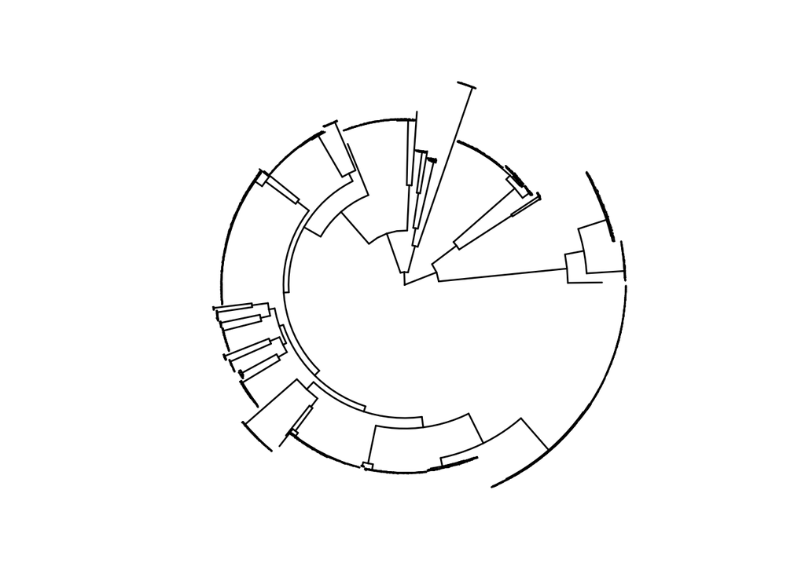

```r
tree <- ape::read.tree("Genetic_pairs_analysis_Oct_2020/raw_data/trees/all_snippy_BPH2947/iqtree.treefile") %>%
  midpoint.root() %>%
  drop.tip("Refere-ce")
ggtree(tree, layout = "circular")
```

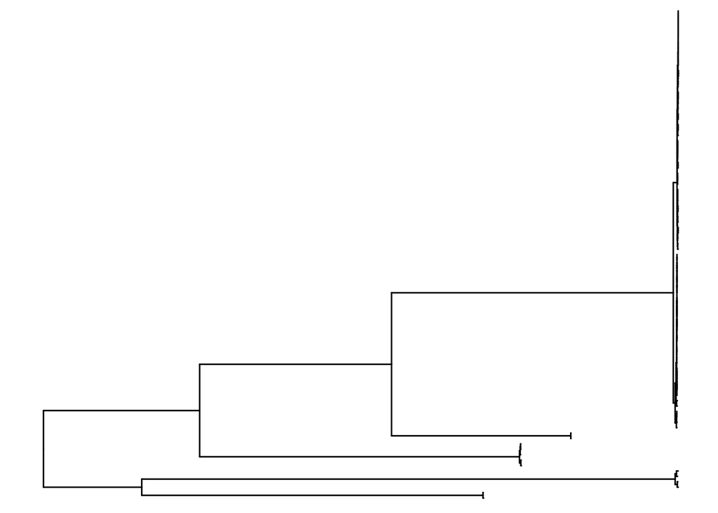

```r
tree_sm <- tree %>%
  drop.tip(setdiff(tree$tip.label, df_monophy_clusters$sample_id))
ggtree(tree_sm)
```

Function to plot mutated gene on tree

```r
plot_mutated_gene_on_tree <- function(tree,
                                      metadata,
                                      gene_id){
  matrix <- metadata %>%
    filter(cdhit_group == gene_id) %>%
    group_by(iso2) %>%
    summarise(MUTATION_SHORT = str_c(unique(MUTATION_SHORT), collapse = " ")) %>%
    column_to_rownames("iso2")

  title <- metadata %>%
    filter(cdhit_group == gene_id) %>%
    group_by(cdhit_group, pan_gene_symbol, neb_locus_tag, neb_mutant_id) %>%
    summarise(gene_prokka = str_c(unique(GENE),
                                collapse = ", "),
            product_prokka = str_c(unique(PRODUCT),
                                   collapse = ", ")) %>%
    unite(col = "title",
          everything(), na.rm = T, sep = "/") %>%
    .$title

  subtitle <- metadata %>%
    filter(cdhit_group == gene_id) %>%
    .$n_events

  p <- gheatmap(ggtree(tree),
                matrix,
                colnames = F, width = .1) +
    scale_fill_brewer(na.translate = F, name = "") +
    labs(title = str_c("cd hit cluster ", title),
         subtitle = str_c(subtitle, " independent mutations"))

  return(p)
                                      }
```

```r
dir <- "Genetic_pairs_analysis_Oct_2020/figures/convergent_genes_mortality/"
dir.create(dir)
for (i in t_converg_genes %>% filter(n_events > 1) %>% arrange(n_events) %>% .$cdhit_group){
  p <- plot_mutated_gene_on_tree(tree_sm,
                                 df_converg_genes,
                                 i)


  # ggsave(str_c(dir, "cd_hit_group_", i, ".pdf"))

}
```

# Assess convergence from snippy on BPH2947

To do

# Save processed data

```r
dir <- "Genetic_pairs_analysis_Oct_2020/processed_data/convergence/"
dir.create(dir)
subdir <- str_c(dir, "mortality/")
dir.create(subdir)
# df_converg_genes %>%
#   saveRDS(str_c(subdir, "df_convergent_genes.Rda"))
# t_converg_genes %>%
#   write_csv(str_c(subdir, "mortality_convergent_genes.csv"))
```